# 2020 Small Stream Analyses

Jay Silvanima

9/12/2021

## Contact:

### James (Jay) Silvanima

Department of Environmental Protection

Watershed Monitoring and Data Management

2600 Blair Stone Road

Tallahassee, Florida 32399-2400

James.Silvanima@dep.state.fl.us

phone: 850-245-8507

fax: 850-245-8554

# **Purpose**

Purpose: Analysis of Florida Stream data generated by the Status Monitoring Program. Created by Jay Silvanima using code developed by Tony Olsen, myself, Chris Sedlacek, Stephanie Sunderman-Barnes, and Liz Miller on 05-07-2021.

Code developed using R version 3.6.2 (2019-12-12), spsurvey version 4.1.0, and FDEPgetdata version 1.4.

This RMarkdown script is based on the R script “2020 SS Script.R” The data used in this example are from 2020.

Load libraries and set working directory or path.

```r
# File: 2020 SS Script.R
##Set directory. This is where the outputs will be saved.
#   Alter to desired location. Use getwd() to determine the directory for
#     your r project.

setwd("C:/R/Status 2020/2020 SS")

# Load libraries for the data analyses

library(FDEPgetdata)
library(spsurvey)
library(sf)
```

```r
library(ggplot2)
```

## **Load Site Information Data**

Load the file SS20_Sites.cvs and create a new data frame from it.

Note that due to the COVID19 pandemic sampling was reduced. For most zones sampling stopped after the fifth site was sampled. The goal was to get at least a sample size for thirty for the entire state.

Convert Lat longs from DDMMSS decimal seconds to degress decimal degress for spsurvy functions. Then create a simple features object and convert to Florida albers projection and plot the evaluated sites. The number of sites will be more than that of those actually sampled because many will have excluded due to various reasons.

```r
SS.SITES <- read.csv('C:/R/Status 2020/2020 SS/SS20_Sites.csv')
names(SS.SITES)
```

```
##  [1] "X"                         "PK_RANDOM_SAMPLE_LOCATION"
##  [3] "FK_EPA_RANDOM_ID"          "NEST1_WT"
##  [5] "EPA_OVERSAMPLE"            "EPA_DIVISION"
##  [7] "STRATUM"                   "MULTIDENSITY_CATEGORY"
##  [9] "WELL_DENSITY"              "WELL_WEIGHT"
## [11] "AQUIFER_WEIGHT"            "RESOURCE_TYPE"
## [13] "REPORTING_UNIT"            "RANDOM_LATITUDE"
## [15] "RANDOM_LONGITUDE"          "HYDROLOGIC_UNIT_CODE"
## [17] "HYDROLOGIC_UNIT_NAME"      "CAN_BE_SAMPLED"
## [19] "EXCLUSION_CATEGORY"        "EXCLUSION_CRITERIA"
## [21] "SAMPLED_DATE"              "HECTARES"
## [23] "ANALYSIS_SUITE"            "LOCATIONAL_DATUM"
## [25] "FK_PROJECT"                "FK_STATION"
## [27] "SAMPLE_LATITUDE"           "SAMPLE_LONGITUDE"
## [29] "FK_WELL_LISTFRAME_ID"      "NUTRIENT_WATERSHED_REGION"
## [31] "SCI_DO_BIOREGION_2012"     "REPORTING_CYCLE"
## [33] "TN_NNC"                    "TP_NNC"
## [35] "DO_Conc"
```

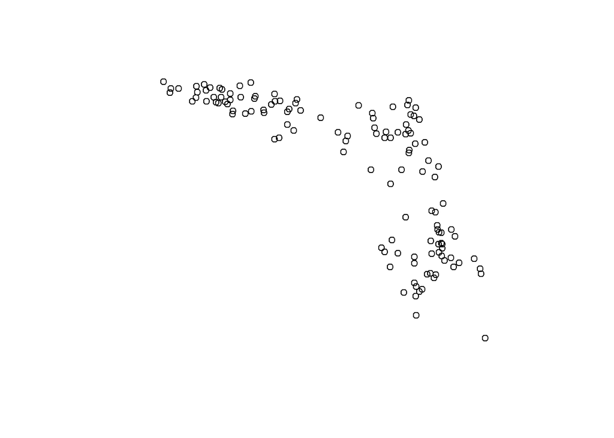

```r
# Convert to Decimal degrees

deg <- floor(SS.SITES$RANDOM_LATITUDE/10000)
min <- floor((SS.SITES$RANDOM_LATITUDE - deg*10000)/100)
sec <- SS.SITES$RANDOM_LATITUDE - deg*10000 - min*100
SS.SITES$latdd <- deg + min/60 + sec/3600
deg <- floor(SS.SITES$RANDOM_LONGITUDE/10000)
min <- floor((SS.SITES$RANDOM_LONGITUDE - deg*10000)/100)
sec <- SS.SITES$RANDOM_LONGITUDE - deg*10000 - min*100
SS.SITES$londd <- deg + min/60 + sec/3600

# Change londd to negative for correct use in sf.
SS.SITES$londd <- -SS.SITES$londd

# Create sf object and transform to Albers projection for analysis
#  This codes utilizes Coordinate Reference System (CRS/EPSG) Codes.
#  The first crs code (4269) below is for NAD 83 coordinate system the
#  second crs code (3087) is for Florida albers projection.
#  More information on these codes is found here:
#  https://www.nceas.ucsb.edu/sites/default/files/2020-04/OverviewCoordinateReferenceSystems.pdf.

dsgn_SS <- st_as_sf(SS.SITES, coords = c("londd", "latdd"), remove = FALSE,
                    crs = 4269)
dsgn_sf <- st_transform(dsgn_SS, crs = 3087)

# keep xy coords as variables
tmp <- st_coordinates(dsgn_sf)
dsgn_sf$xcoord <- tmp[, "X"]
dsgn_sf$ycoord <- tmp[, "Y"]

# plot sites using sf
plot(st_geometry(dsgn_sf))
```

## *Determine which sites belong in the target population*

The variables CAN_BE_SAMPLED, EXCLUSION_CATEGORY and EXCLUSION_CRITERIA provide information on the site evaluation results for each site. Review the information and create target/nontarget (TNT) variable.Create sampled and target (T) / nontarget (NT) variables.

Adjust sample weights for design as Implemented.

```r
# Site Evaluation

addmargins(table(dsgn_sf$EXCLUSION_CATEGORY, dsgn_sf$CAN_BE_SAMPLED, useNA = 'ifany'))
```

```
##
##                                                  N   Y Sum
##   DRY                                            4   0   4
##   NO PERMISSION FROM OWNER                      49   0  49
##   OTHERWISE UNSAMPLEABLE                         4   0   4
##   UNABLE TO ACCESS                              19   0  19
##   WRONG RESOURCE/NOT PART OF TARGET POPULATION  12   0  12
##   <NA>                                           0  38  38
##   Sum                                           88  38 126
```

```r
addmargins(table(dsgn_sf$EXCLUSION_CRITERIA, useNA = 'ifany'))
```

```
##
##                                                                   ACCESS DENIED BY PROPERTY OWNER
##                                                                                                18
##                                                                         DRAINAGE/IRRIGATION DITCH
##                                                                                                 2
##    DRY DURING INDEX PERIOD, INCLUDES SMALL LAKE WATER < 4 HECTARES LARGE LAKE WATER < 10 HECTARES
##                                                                                                 2
##                        FLOOD CONDITIONS (FLOW OUT OF BANKS) AT STREAM/RIVER/CANAL RANDOM LOCATION
##                                                                                                 4
##                                  GIS COVERAGE INCORRECT, WATERBODY NOT PRESENT AT RANDOM LOCATION
##                                                                                                 5
##                                                              RANDOM LOCATION LESS THAN 10 CM DEEP
##                                                                                                 2
## STREAM/RIVER ARTIFICIALLY ALTERED WITH LOSS OF SINUOSITY AND BOX CUT BANKS (NOT A PRIMARY CANAL).
##                                                                                                 3
##                                                        UNABLE TO GET EQUIPMENT TO RANDOM LOCATION
##                                                                                                18
##                                                            UNABLE TO OBTAIN PERMISSION FROM OWNER
##                                                                                                31
##                              UNABLE TO REACH RANDOM LOCATION WITHIN THREE HOURS FROM ACCESS POINT
##                                                                                                 1
##                                                                                          WETLANDS
##                                                                                                 2
##                                                                                              <NA>
##                                                                                                38
##                                                                                               Sum
##                                                                                               126
```

```r
# create sampled and target (T) / nontarget (NT) variables

dsgn_sf$EXCLUSION_CATEGORY <- as.character(dsgn_sf$EXCLUSION_CATEGORY)
dsgn_sf$EXCLUSION_CATEGORY[dsgn_sf$CAN_BE_SAMPLED == 'Y'] <- 'SAMPLED'
dsgn_sf$EXCLUSION_CATEGORY <- as.factor(dsgn_sf$EXCLUSION_CATEGORY)
levels(dsgn_sf$EXCLUSION_CATEGORY)
```

```
## [1] "DRY"
## [2] "NO PERMISSION FROM OWNER"
## [3] "OTHERWISE UNSAMPLEABLE"
## [4] "SAMPLED"
## [5] "UNABLE TO ACCESS"
## [6] "WRONG RESOURCE/NOT PART OF TARGET POPULATION"
```

```r
dsgn_sf$TNT <- dsgn_sf$EXCLUSION_CATEGORY
levels(dsgn_sf$TNT) <- list(T=c('SAMPLED', 'NO PERMISSION FROM OWNER', 'UNABLE TO ACCESS','OTHERWISE UNSAMPLEABLE','DRY'),
                            NT=c('WRONG RESOURCE/NOT PART OF TARGET POPULATION') )

addmargins(table(dsgn_sf$EXCLUSION_CATEGORY, dsgn_sf$TNT, useNA = 'ifany'))
```

```
##
##                                                  T  NT Sum
##   DRY                                            4   0   4
##   NO PERMISSION FROM OWNER                      49   0  49
##   OTHERWISE UNSAMPLEABLE                         4   0   4
##   SAMPLED                                       38   0  38
##   UNABLE TO ACCESS                              19   0  19
##   WRONG RESOURCE/NOT PART OF TARGET POPULATION   0  12  12
##   Sum                                          114  12 126
```

We evaluated 126 stream locations and determined that 12 were non-target, and of the 114 which were target 38 were able to be sampled.

## *Adjust weights for Design As Implemented*

Per Tony Olsen, “The initial design weights must be adjusted to account for the actual number of sites evaluated. The weight adjustment requires knowing the stream lengths in the sample frame. First, create the framesize using stream kilometers from that 2020 stream design document. The initial design weights are in the column”NEST1_WT" and the weight adjustment categories are the six reporting units."

Note need frame size here found in design doc for stream site selections. From design document framesize in kilometers = 24,380.196 for entire data frame.

```r
# Note need frame size here found in design doc for stream site selections
#  Z:\Chris site selection process\2020 site selections\2020 SS\Florida 2020 stream Design.doc
#  From design document framesize in kilometers = 24,380.196 for entire data frame.

framesize <- c("ZONE 1"=12342.640 ,"ZONE 2"=2212.137,
                "ZONE 3"=4424.757 ,"ZONE 4"=4211.302,
                "ZONE 5"=1006.819 ,"ZONE 6"=182.541)

# use all evaluated sites to adjust weights
nr <- nrow(dsgn_sf)
dsgn_sf$wgt <- adjwgt(rep(TRUE,nr), dsgn_sf$NEST1_WT,
                      dsgn_sf$REPORTING_UNIT, framesize=framesize)

# check sum of weights for each reporting unit/basin
addmargins(tapply(dsgn_sf$wgt, dsgn_sf$REPORTING_UNIT, sum))
```

```
##    ZONE 1    ZONE 2    ZONE 3    ZONE 4    ZONE 5    ZONE 6       Sum
## 12342.640  2212.137  4424.757  4211.302  1006.819   182.541 24380.196
```

```r
# This gives the weights for the stream design as implemented in 2020.
# It must include all evaluated sites as some sites are not in the
#  target population.
```

## *Estimate Extent of Stream Kilometers in Target Population*

Since the sample frame includes portions of small stream object segments that do not meet the definition of a small stream, the site evaluation information is used to estimate the small stream kilometers in the target population for entire state and for each of the reporting units/basins.

```r
# Estimate Extent Stream Kilometers.
# Since the sample frame includes portions of stream object line segments that do not
#  meet the definition of a stream, the site evaluation information is used
#  to estimate the stream kilometers in the target population for entire state and for
#  each of the reporting units/basins.

sites <- data.frame(siteID = dsgn_sf$PK_RANDOM_SAMPLE_LOCATION, Use=rep(TRUE,nr) )
subpop <- data.frame(siteID = dsgn_sf$PK_RANDOM_SAMPLE_LOCATION,
                     Combined = rep("All Basins", nr),
                     Basin = dsgn_sf$REPORTING_UNIT)
dsgn <- data.frame(siteID = dsgn_sf$PK_RANDOM_SAMPLE_LOCATION,
                   wgt = dsgn_sf$wgt,
                   xcoord = dsgn_sf$xcoord,
                   ycoord = dsgn_sf$ycoord,
                   stratum = dsgn_sf$REPORTING_UNIT)

data.cat <- data.frame(siteID = dsgn_sf$PK_RANDOM_SAMPLE_LOCATION,
                       TNTStatus=dsgn_sf$TNT,
                       EXCLUSION.CATEGORY = dsgn_sf$EXCLUSION_CATEGORY)

ExtentEst <- cat.analysis(sites, subpop, dsgn, data.cat, conf=95)

# write out or export results
write.csv(ExtentEst,file = 'ExtentEst.csv')
```

Of the 24,380.196 stream kilometers in the sample frame, 90.4% are estimated to be in the target population. Also, only 30.0% of the sample frame could actually be sampled. To estimate the percent of the target population that could be sampled, requires that the analysis be restricted to just sites in the target population, i.e., TNT = “T”

```r
sites <- data.frame(siteID = dsgn_sf$PK_RANDOM_SAMPLE_LOCATION, Use = dsgn_sf$TNT == "T" )
subpop <- data.frame(siteID = dsgn_sf$PK_RANDOM_SAMPLE_LOCATION,
                     Combined = rep("All Basins", nr),
                     Basin = dsgn_sf$REPORTING_UNIT)
dsgn <- data.frame(siteID = dsgn_sf$PK_RANDOM_SAMPLE_LOCATION,
                   wgt = dsgn_sf$wgt,
                   xcoord = dsgn_sf$xcoord,
                   ycoord = dsgn_sf$ycoord,
                   stratum = dsgn_sf$REPORTING_UNIT)

data.cat <- data.frame(siteID = dsgn_sf$PK_RANDOM_SAMPLE_LOCATION,
                       EXCLUSION.CATEGORY = dsgn_sf$EXCLUSION_CATEGORY)

ExtentEst_Target <- cat.analysis(sites, subpop, dsgn, data.cat, conf=95)

# write out or export results
write.csv(ExtentEst_Target, file = 'ExtentEst_Target.csv')

# 33.1% of the target population area could be sampled, i.e.,
#  7303.2 kilometers CI(5350.4, 9256.1)
```

## **Load Water Quality Data**

```r
SS_RSLTS <- read.csv('C:/R/Status 2020/2020 SS/SS20_Results.csv')

# Create new data frame from the one just loaded.

names(SS_RSLTS)
```

```
##   [1] "X"
##   [2] "FK_STATION"
##   [3] "FK_RANDOM_SAMPLE_LOCATION"
##   [4] "FK_SAMPLE"
##   [5] "COLLECTION_DATE"
##   [6] "SAMPLE_TYPE"
##   [7] "MATRIX"
##   [8] "MATRIX_VQ"
##   [9] "Turbidity_Lab"
##  [10] "Turbidity_Lab_VQ"
##  [11] "Alkalinity_Total_as_CaCO3"
##  [12] "Alkalinity_Total_as_CaCO3_VQ"
##  [13] "Total_Dissolved_Solids_TDS_measured"
##  [14] "Total_Dissolved_Solids_TDS_measured_VQ"
##  [15] "Pheophytin_A_Monochromatic"
```

[output cut: 101 more lines]

```r
# Determine sample types in file.
addmargins(table(SS_RSLTS$SAMPLE_TYPE, SS_RSLTS$MATRIX, useNA = 'ifany'))
```

```
##
##               WATER Sum
##   BOTTOM         10  10
##   FIELD BLANK     8   8
##   PRIMARY        38  38
##   Sum            56  56
```

## **Load Water Quality Data**

Water quality analyses are based on 38 sites from the results file and must be merged with design information. This merge will remove any result data marked as inappropriate for Status Network analysis (i.e. where pk_random_sample_location contains “B”).

```r
# Note that have BLANK, BOTTOM and PRIMARY data and matrix types.
# Only want to use PRIMARY results for population estimation.

keep <- SS_RSLTS$SAMPLE_TYPE == 'PRIMARY' & SS_RSLTS$MATRIX == 'WATER'

# merge with exclusion file
SS_WQ <- merge(as.data.frame(dsgn_sf)[, c("PK_RANDOM_SAMPLE_LOCATION",
                "REPORTING_UNIT", "EXCLUSION_CATEGORY","TNT", "wgt",
                "londd", "latdd", "xcoord", "ycoord", "TN_NNC", "TP_NNC",
                "DO_Conc")], SS_RSLTS[keep,],
               by.x = 'PK_RANDOM_SAMPLE_LOCATION',
               by.y = 'FK_RANDOM_SAMPLE_LOCATION')

# check that have only PRIMARY for Water MATRIX data
addmargins(table(SS_WQ$SAMPLE_TYPE, SS_WQ$MATRIX, useNA = 'ifany'))
```

```
##
##               WATER Sum
##   BOTTOM          0   0
##   FIELD BLANK     0   0
##   PRIMARY        38  38
##   Sum            38  38
```

## **Ammonia Calculation for Threshold**

Calculates total ammonia from single sample criteria

Code chunk written 1/6/2020 by Stephanie Sunderman Barnes. Calculator for total ammonia nitrogen (TAN) single sample criteria. Created using TAN calculator spreadsheet as a guide (accessed 1/3/2020, https://floridadep.gov/dear/water-quality-standards-program/documents/total-ammonia-nitrogen-calculator%C2%A0).

```r
##TotAmm.pH = pH used in ammonia calc. If measured pH < 6.5, value used is 6.5. If meas. pH > 9.0, value used is 9.0.
SS_WQ$TotAmm_pH <- ifelse(SS_WQ$pH_Field < 6.5, 6.5,
                         ifelse(SS_WQ$pH_Field > 9.0, 9.0,SS_WQ$pH_Field))

##TotAmm.temp = water temperature used in ammonia calc. If measured temp < 7 degrees C, value used is 7.
SS_WQ$TotAmm_temp <- ifelse(SS_WQ$Water_Temperature < 7, 7, SS_WQ$Water_Temperature )

##calculate single sample Total Ammonia Criteria using TotAmm.pH and TotAmm.temp
SS_WQ$TotAmmCrit_SingleSamp <- ifelse(is.na(SS_WQ$TotAmm_pH), NA,
                                     ifelse(is.na(SS_WQ$TotAmm_temp), NA,
                                            (2.5*(0.8876*((0.0278/(1+10^(7.688-SS_WQ$TotAmm_pH)))+(1.1994/(1+10^(SS_WQ$TotAmm_pH-7.688))))*2.126*10^(0.028*(20-(SS_WQ$TotAmm_temp)))))))

##Round result to two decimal places
SS_WQ$TotAmmCrit_SingleSamp <- round(SS_WQ$TotAmmCrit_SingleSamp, digits=2)

##Run analysis similar to NNC using the single sample total ammonia criteria calculated above
### Pass=1 AND Fail=0
SS_WQ$TAmm_Cat<-ifelse((SS_WQ$TotAmmCrit_SingleSamp >= SS_WQ$Ammonia_Total_as_N),1,0)

#########End Ammonia Calculation
```

## **Set up threshold category columns for remainder of analytes**

E_Coli category

```r
E_Coli_cat <- cut(SS_WQ$Escherichia_Coli_Quanti_Tray, breaks=c(0,409,10000000), include.lowest=TRUE)
SS_WQ$E_Coli_cat <- E_Coli_cat
SS_WQ$E_Coli_cat <- as.factor(SS_WQ$E_Coli_cat)
```

Old Dissolved Oxygen Category

```r
DO_cat_old <- cut(SS_WQ$Oxygen_Dissolved_Field, breaks=c(0,4.999,1000000), include.lowest=TRUE)
SS_WQ$DO_cat_old <- DO_cat_old
SS_WQ$DO_cat_old <- as.factor(SS_WQ$DO_cat_old)
```

pH Category

```r
pH_cat <- cut(SS_WQ$pH_Field, breaks=c(0,5.999,8.5,14), include.lowest=TRUE)
SS_WQ$pH_cat <- pH_cat
SS_WQ$pH_cat <- as.factor(SS_WQ$pH_cat)
```

Chlorophyll Category

```r
Chlorophyll_cat <- cut(SS_WQ$Chlorophyll_A_Monochromatic, breaks=c(0,20,10000), include.lowest=TRUE)
SS_WQ$Chlorophyll_cat <- Chlorophyll_cat
SS_WQ$Chlorophyll_cat <- as.factor(SS_WQ$Chlorophyll_cat)
```

Calculate Total Nitrogen (TN) as sum of TKN & NO3NO2.

Numeric Nutrient and DO Categories Note Pass=1 AND Fail=0 Total NNC category = sum of category results for TN, TP, and DO. If Tot_cat = 3, sample passed criteria for these 3 parameters.

```r
SS_WQ$TN<-(SS_WQ$Kjeldahl_Nitrogen_Total_as_N+SS_WQ$NitrateNitrite_Total_as_N)

SS_WQ$TN_cat<-ifelse((SS_WQ$TN_NNC >= SS_WQ$TN),1,0)

SS_WQ$TP_cat<-ifelse((SS_WQ$TP_NNC >= SS_WQ$Phosphorus_Total_as_P),1,0)

SS_WQ$DO_cat<-ifelse((SS_WQ$Oxygen_Dissolved_Percent_Saturation >= SS_WQ$DO_Conc ),1,0)

SS_WQ$Tot_cat<-(SS_WQ$TN_cat+SS_WQ$TP_cat+SS_WQ$DO_cat)

##### End setting up categories for water quality indicators

nr <- nrow(SS_WQ)
levels(SS_WQ$TNT)
```

```
## [1] "T"  "NT"
```

## **Continuous Water Quality Indicator Indicator Estimates**

```r
sites_WQ <- data.frame(siteID = SS_WQ$PK_RANDOM_SAMPLE_LOCATION, Use = SS_WQ$TNT == "T" )
subpop_WQ <- data.frame(siteID = SS_WQ$PK_RANDOM_SAMPLE_LOCATION,
                        Combined = rep("All Basins", nrow(SS_WQ)),
                        Basin = SS_WQ$REPORTING_UNIT)
dsgn_WQ <- data.frame(siteID = SS_WQ$PK_RANDOM_SAMPLE_LOCATION,
                      wgt = SS_WQ$wgt,
                      xcoord = SS_WQ$xcoord,
                      ycoord = SS_WQ$ycoord,
                      stratum = SS_WQ$REPORTING_UNIT)

# continuous WQ estimates

data.cont.WQ <- data.frame(siteID=SS_WQ$PK_RANDOM_SAMPLE_LOCATION,
                           SS_WQ[,c('Oxygen_Dissolved_Field','pH_Field','Escherichia_Coli_Quanti_Tray',
                                    'Chlorophyll_A_Monochromatic','Ammonia_Total_as_N','TN','Phosphorus_Total_as_P')])
Water_quality_Cont <- cont.analysis(sites = sites_WQ, subpop = subpop_WQ,
                               design = dsgn_WQ, data.cont = data.cont.WQ, conf=95)
```

## **Categorical Water Quality Indicator Indicator Estimates**

```r
data.cat.wq <- data.frame(siteID = SS_WQ$PK_RANDOM_SAMPLE_LOCATION,
                           Ammonia_Category = SS_WQ$TAmm_Cat,
                           Chlorophyll_Category = SS_WQ$Chlorophyll_cat,
                           TN_Category = SS_WQ$TN_cat,
                           TP_Category = SS_WQ$TP_cat,
                           DO_Category = SS_WQ$DO_cat,
                           TN_TP_DO_Category = SS_WQ$Tot_cat,
                           E_Coli_Category = SS_WQ$E_Coli_cat,
                           pH_Category = SS_WQ$pH_cat)

Water_Quality_Cat <- cat.analysis(sites = sites_WQ, subpop = subpop_WQ,
                             design = dsgn_WQ, data.cat = data.cat.wq, conf=95)
```

## **Write Out The Results**

```r
write.csv(Water_Quality_Cat, "2020_SS_Cat.csv")
write.csv(Water_quality_Cont$CDF, file = '2020_SS_Cont_EstCDF.csv')
write.csv(Water_quality_Cont$Pct, file = '2020_SS_Cont_EstPCT.csv')

####
#######################################################################################
####
######################################################################################
```